# bulkRNAseq_shiny_app version 1.0.0

Katarzyna Sikora

14/6/2019

## What the app takes as input

- A count table such as produced by featurecounts, with samples in columns and genes (ensembl or encode IDs) in rows. Raw (unnormalized) integer counts are expected.
- A headerless txt file with a list of ensembl/encode gene IDs matching the counttable gene IDs to use for plotting.
- Optional: organism to use for conversion of gene IDs to gene symbols.

## What the app can do

- Normalize and transform raw data to log2CPMs
- Produce a downloadable table of log2CPMs for user gene list
- Produce a heatmap of z-scores based on the above table
- Produce a jitter plot using log2CPMs based on the above table

## How the app works

- User uploads a counts table, a header-less one-column table with gene IDs and fills out grouping information in the sample sheet.
- Size factors are calculated for samples using all genes, and voom is applied to transform data to log2CPM.

## Example usage

Select mouse mm10 as organism and upload a count table for a published data under /data/processing/bulkRNAseq_app_example_data/counts.tsv in the “Upload feature counts table” field (Figure 1). In the Input Annotation tab, a sample sheet will be generated instaneously(Figure 2)

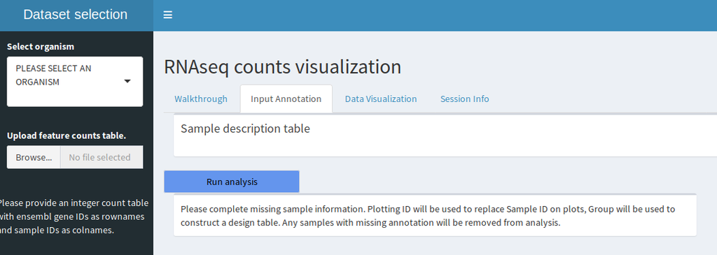

Figure 1: Initial information

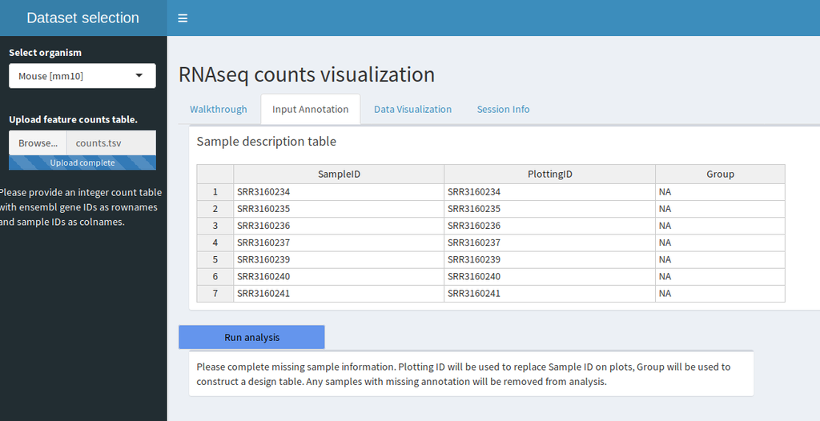

Figure 2: Organism and counts table were provided

Provide grouping information for the samples. Provide e.g. “a” for the first four samples, and “b” for the last 3 samples in the table . If all displays correctly, click on the “Run analysis” button below the sample table. After the normalization is completed, a notification will appear (Figure 3).

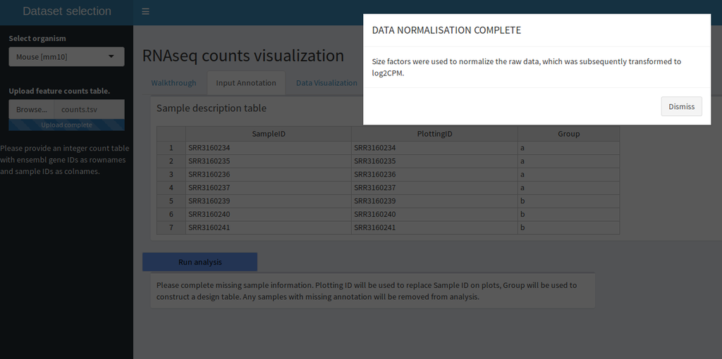

Figure 3: Grouping information was provided and analysis run requested

In the tab “Data Visualization”, you will find a heatmap of z-scores, as well as a jitter plot, both calculated for randomly selected genes (Figure 4).

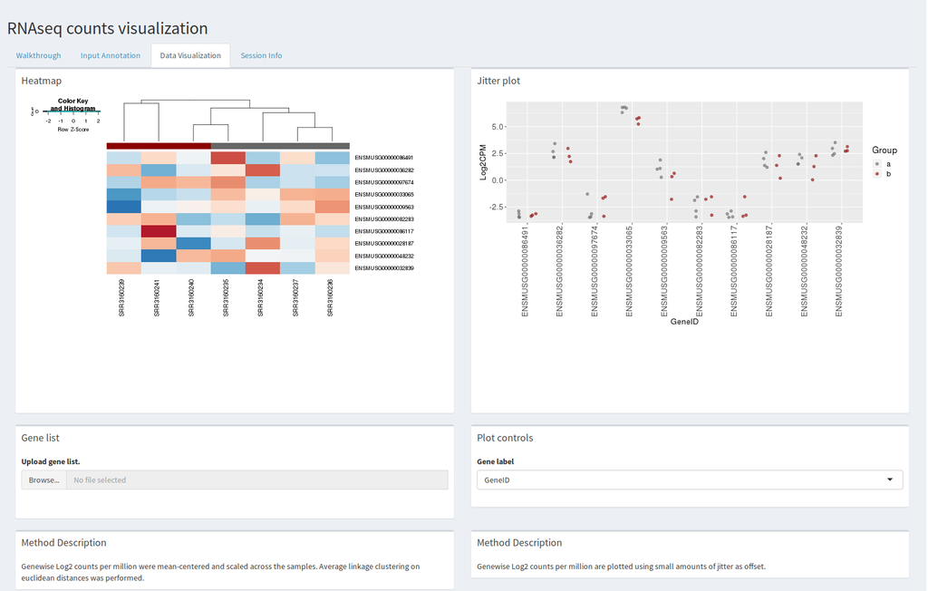

Figure 4: Plots were initialized with random data

Upload a file with a headerless 1-column table of gene IDs matching your counts table and both plots will update accordingly (Figure 5).

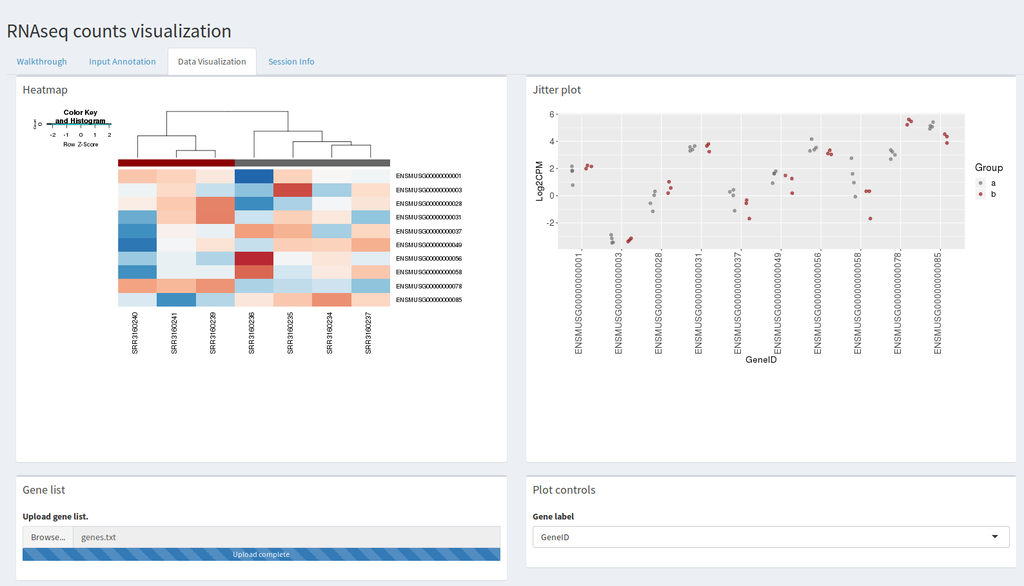

Figure 5: Gene list was uploaded and plots were updated

If you have provided an organism matching your data in the sidebar, you may switch to Gene Symbol instead of Gene ID in the Plot controls box. Otherwise, gene IDs will be kept.

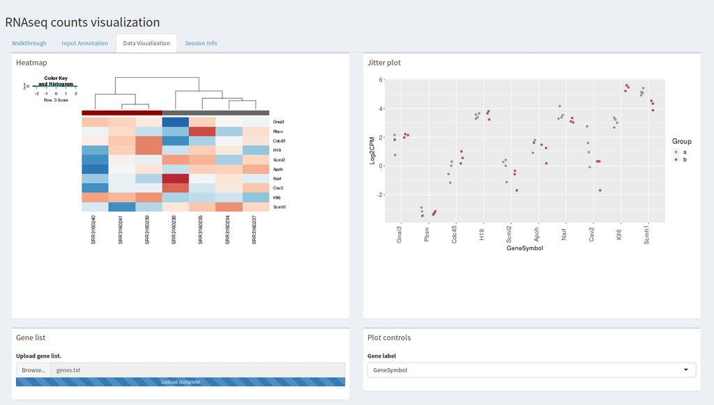

Figure 6: Gene Symbols were used instead of Gene IDs

At the bottom of the page, you may download the table of normalized counts underlying both plots (Figure 7).

[figure not shown]

Figure 7: Normalized counts table download was requested

In the Session Info tab, you will find the sessionInfo information to keep track of package versions used for the analysis (Figure 8).

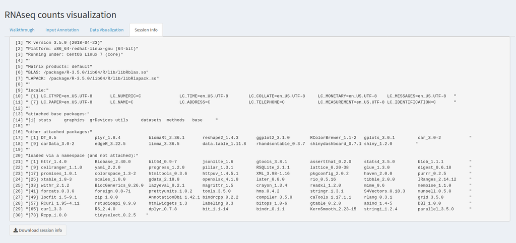

Figure 8: Session info